# Лабораторная работа №16

Дисциплина: Администрирование сетевых подсистем

Бахи сиди али темассини

1032234211@pfur.ru

Российский университет дружбы народов

2026-02-16

# Цель работы

## Цель работы

- Получение навыков работы с Fail2ban
- Настройка базовой защиты от атак типа brute force

# Выполнение лабораторной работы

## Защита с помощью Fail2ban

### Установка Fail2ban

- Установлен пакет `fail2ban` через `dnf`
- Установлены зависимости: `fail2ban-firewalld`, `fail2ban-selinux`, `fail2ban-sendmail`, `fail2ban-server`
- Использован репозиторий `epel`

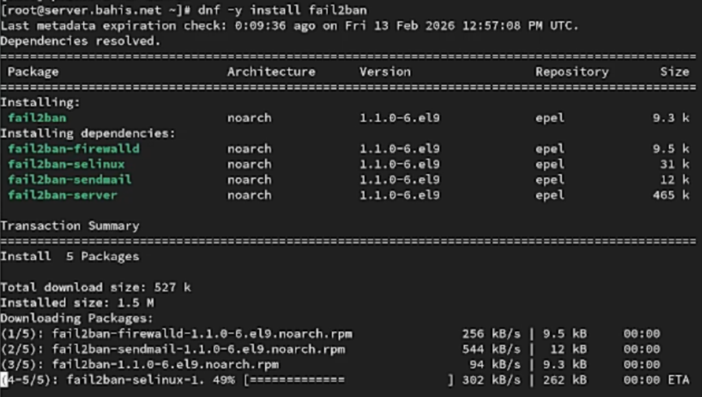

Рисунок 1: Установка пакета fail2ban и зависимостей через dnf

### Запуск и добавление службы в автозагрузку

- Выполнен `systemctl start fail2ban`
- Выполнен `systemctl enable fail2ban`
- Создана ссылка в `multi-user.target.wants`

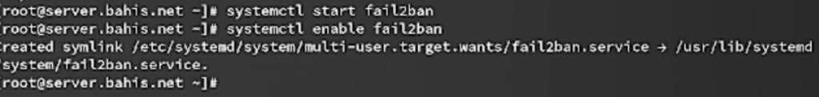

Рисунок 2: Запуск службы fail2ban и включение автозагрузки

### Контроль журнала событий Fail2ban

- Выполнен `tail -f /var/log/fail2ban.log`
- Зафиксирован запуск Fail2ban 1.1.0
- Инициализирован observer
- Создана база `fail2ban.sqlite3`

[figure not shown]

Рисунок 3: Просмотр журнала fail2ban.log в реальном времени

### Создание файла локальной конфигурации

- Создан файл `/etc/fail2ban/jail.d/customisation.local`
- Выполнено редактирование в `nano`

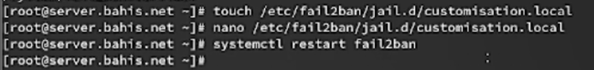

Рисунок 4: Создание и перезапуск службы после настройки

### Настройка параметров блокирования и защиты SSH

- В `[DEFAULT]` установлен `bantime = 3600`
- Активированы `[sshd]`, `[sshd-ddos]`, `[selinux-ssh]`
- Указан порт `ssh,2022`
- Для всех секций `enabled = true`

[figure not shown]

Рисунок 5: Конфигурация customisation.local с параметрами bantime и SSH

### Перезапуск службы Fail2ban

- Выполнен `systemctl restart fail2ban`
- Применена новая конфигурация

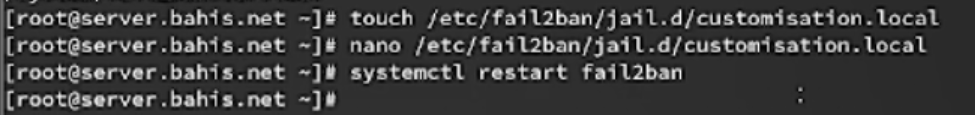

Рисунок 6: Создание и перезапуск службы после настройки

### Просмотр журнала после настройки SSH

- Инициализирован backend `pyinotify`
- Установлены параметры `maxRetry`, `findtime`, `banTime = 3600`
- Запущены jail-модули `sshd`, `selinux-ssh`, `sshd-ddos`

[figure not shown]

Рисунок 7: Журнал запуска jail-модулей SSH в fail2ban

### Включение защиты HTTP

- Активированы jail-модули: `apache-auth`, `apache-badbots`, `apache-noscript`, `apache-overflows`, `apache-nohome`, `apache-botsearch`, `apache-fakegooglebot`, `apache-modsecurity`, `apache-shellshock`
- Для всех `enabled = true`

[figure not shown]

Рисунок 8: Конфигурация HTTP jail-модулей в customisation.local

### Перезапуск после настройки HTTP

- Выполнен `systemctl restart fail2ban`
- Загружены HTTP jail-модули

[figure not shown]

Рисунок 9: Журнал запуска HTTP jail-модулей

### Контроль журнала HTTP-защиты

- В журнале зафиксирован запуск всех `apache-*` jail
- Подтверждена активация `sshd-ddos`

[figure not shown]

Рисунок 10: Подтверждение запуска HTTP jail-модулей в журнале

### Включение защиты почтовых сервисов

- Активированы jail-модули: `postfix`, `postfix-rbl`, `dovecot`, `postfix-sasl`
- Установлено `enabled = true`

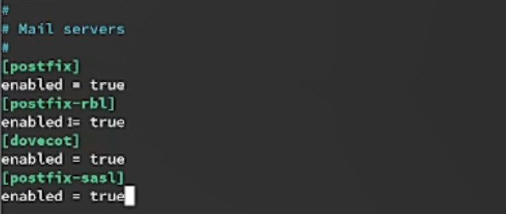

Рисунок 11: Конфигурация jail-модулей для почтовых сервисов

### Перезапуск после настройки почтовых служб

- Выполнен перезапуск `fail2ban`
- Загружены почтовые jail-модули

[figure not shown]

Рисунок 12: Журнал запуска jail-модулей почтовых сервисов

### Контроль журнала почтовой защиты

- Зафиксировано `Jail is in operation now`
- Подтверждена активация `postfix`, `dovecot`, `postfix-sasl`

[figure not shown]

Рисунок 13: Подтверждение работы jail-модулей почтовых сервисов

## Проверка работы Fail2ban

### Просмотр общего статуса

- Выполнен `fail2ban-client status`
- Активировано 16 jail-модулей
- Отображены `apache-*`, `sshd`, `dovecot`, `postfix`

### Просмотр статуса SSH

- Выполнен `fail2ban-client status sshd`
- `Currently banned: 0`
- `Total banned: 0`

### Установка maxretry

- Выполнено `fail2ban-client set sshd maxretry 2`
- После 2 ошибок IP должен блокироваться

### Попытка входа с неверным паролем

### Проверка блокировки IP

[figure not shown]

### Разблокировка IP

- Выполнено `fail2ban-client set sshd unbanip 192.168.1.30`

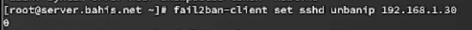

Рисунок 18: Команда разблокировки IP-адреса клиента

### Проверка снятия блокировки

- Повторный `status sshd`
- `Currently banned: 0`
- Список пуст

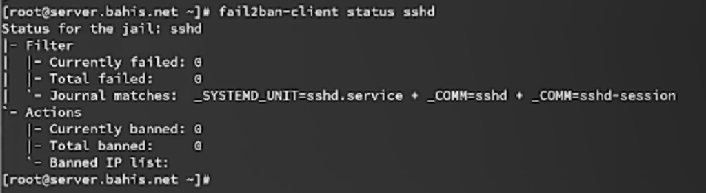

Рисунок 19: Статус sshd после снятия блокировки

### Добавление ignoreip

[figure not shown]

Рисунок 20: Добавление параметра ignoreip в customisation.local

### Просмотр журнала ignoreip

[figure not shown]

### Повторная проверка SSH

- Повторные ошибки входа не приводят к блокировке
- `Currently banned: 0`
- Список IP пуст

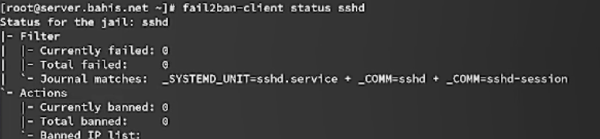

Рисунок 22: Статус sshd после включения ignoreip

## Внесение изменений в настройки внутреннего

### Подготовка конфигурации

- Создан каталог `protect/etc/fail2ban/jail.d`
- Скопирован `customisation.local`

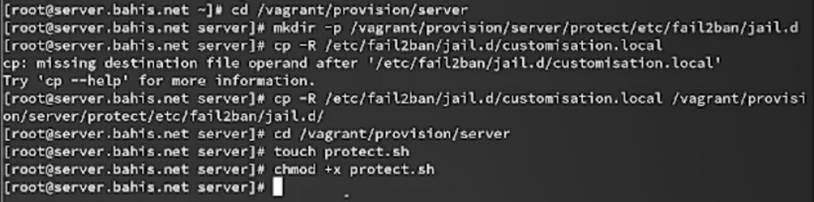

Рисунок 23: Создание каталога protect и копирование customisation.local

### Создание скрипта protect.sh

- Установка `fail2ban`
- Копирование конфигурации в `/etc`
- Выполнен `restorecon -vR /etc`
- Включена и запущена служба

[figure not shown]

Рисунок 24: Содержимое скрипта protect.sh

### Добавление provisioning в Vagrantfile

- Добавлен блок `server.vm.provision`
- Указан путь `provision/server/protect.sh`
- Использован `preserve_order: true`

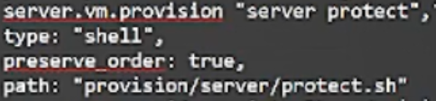

Рисунок 25: Добавление блока provision в Vagrantfile

# Выводы

## Выводы

- Установлен и настроен Fail2ban
- Реализована защита SSH, HTTP и почтовых сервисов
- Проверена блокировка IP при превышении `maxretry`
- Выполнена ручная разблокировка
- Настроен параметр `ignoreip`
- Подтверждена корректная работа jail-модулей
- Настройка автоматизирована через provisioning
- Обеспечена воспроизводимая базовая защита от brute force